# DESeq-crabsABC-crabsGHI

Rmd to use `DESeq2` to get differentially expressed gene list from comparing Crabs A, B, and C (infected, ambient - day 2) to Crabs G, H, and I (infected, elevated - day 2). Crabs A, B, and C will be combined into 1 group (infected, ambient, day 2) and crabs G, H, and I will be combined in 1 group (infected, elevated, day 2).

```r
library(DESeq2)
library(dplyr)
library(tidyverse)
```

Read in the isoform count matrix from the 2020 Genewiz individual crab RNAseq data (un-normalized!!):

```r
indiv_counts <- read.delim("../data/individual_crab-salmon.isoform.counts.matrix")
head(indiv_counts)
```

```
##                          X X294_quant X254_quant X280_quant X485_quant
## 1  TRINITY_DN5772_c0_g1_i1          0          0      0.000          0
## 2  TRINITY_DN2201_c0_g1_i1          5          0      5.823          0
## 3  TRINITY_DN4656_c0_g1_i1         19         36      4.000         12
## 4  TRINITY_DN7591_c0_g1_i1         16          3      2.000          1
## 5  TRINITY_DN6285_c0_g1_i4          0          0      0.000          4
## 6 TRINITY_DN28918_c0_g1_i1          0          0      0.000          0
##   X481_quant X173_quant X222_quant X151_quant X272_quant X132_quant X127_quant
## 1          0          0          0          0          0          0          0
## 2          0          0          5          0          0          0          0
## 3          8         74          8         53          0          7         18
## 4         15          0         11         17          0          0         41
## 5          0          0          0          0          0          0          0
## 6          1          0          0          0          0          0          1
##   X73_quant X427_quant X118_quant X334_quant X349_quant X425_quant X178_quant
## 1         0          0          0          0          0          0          0
## 2         0          0          0          0          0          0          0
## 3         0          0          4          3          0          0         37
## 4         0          0          2          0          0          0          3
## 5         0          0          0          0          0          0          0
## 6         0          0          0          0          0          0          2
##   X72_quant X463_quant X221_quant X445_quant X359_quant X113_quant
## 1         0          0          0      0.000          3      0.000
## 2         0          0          0     80.000          0     28.449
## 3         7          0          0     20.000         35     14.000
## 4         0          0          0     38.000         25     36.000
## 5         0          0          0      5.946          0      0.000
## 6         0          0          0      0.000          0      0.000
```

We only want day 2 samples from crabs A, B, C and G, H, I Crab A day 2 - 359 Crab B day 2 - 349 Crab C day 2 - 334 Crab G day 2 - 272 Crab H day 2 - 294 Crab I day 2 - 280

ALSO! Select the first column “X” with Trinity IDs

Subset those columns:

```r
abcghi <- select(indiv_counts, X, X359_quant, X349_quant, X334_quant, X272_quant, X294_quant, X280_quant)
head(abcghi)
```

```
##                          X X359_quant X349_quant X334_quant X272_quant
## 1  TRINITY_DN5772_c0_g1_i1          3          0          0          0
## 2  TRINITY_DN2201_c0_g1_i1          0          0          0          0
## 3  TRINITY_DN4656_c0_g1_i1         35          0          3          0
## 4  TRINITY_DN7591_c0_g1_i1         25          0          0          0
## 5  TRINITY_DN6285_c0_g1_i4          0          0          0          0
## 6 TRINITY_DN28918_c0_g1_i1          0          0          0          0
##   X294_quant X280_quant
## 1          0      0.000
## 2          5      5.823
## 3         19      4.000
## 4         16      2.000
## 5          0      0.000
## 6          0      0.000
```

Rename columns:

```r
colnames(abcghi) <- c("X", "359_ambient", "349_ambient", "334_ambient", "272_elevated", "294_elevated", "280_elevated")
head(abcghi)
```

```
##                          X 359_ambient 349_ambient 334_ambient 272_elevated
## 1  TRINITY_DN5772_c0_g1_i1           3           0           0            0
## 2  TRINITY_DN2201_c0_g1_i1           0           0           0            0
## 3  TRINITY_DN4656_c0_g1_i1          35           0           3            0
## 4  TRINITY_DN7591_c0_g1_i1          25           0           0            0
## 5  TRINITY_DN6285_c0_g1_i4           0           0           0            0
## 6 TRINITY_DN28918_c0_g1_i1           0           0           0            0
##   294_elevated 280_elevated
## 1            0        0.000
## 2            5        5.823
## 3           19        4.000
## 4           16        2.000
## 5            0        0.000
## 6            0        0.000
```

Make Column X (Trinity IDs) row names:

```r
rownames(abcghi) <- abcghi$X
abcghi <- abcghi[,-1]
head(abcghi)
```

```
##                          359_ambient 349_ambient 334_ambient 272_elevated
## TRINITY_DN5772_c0_g1_i1            3           0           0            0
## TRINITY_DN2201_c0_g1_i1            0           0           0            0
## TRINITY_DN4656_c0_g1_i1           35           0           3            0
## TRINITY_DN7591_c0_g1_i1           25           0           0            0
## TRINITY_DN6285_c0_g1_i4            0           0           0            0
## TRINITY_DN28918_c0_g1_i1           0           0           0            0
##                          294_elevated 280_elevated
## TRINITY_DN5772_c0_g1_i1             0        0.000
## TRINITY_DN2201_c0_g1_i1             5        5.823
## TRINITY_DN4656_c0_g1_i1            19        4.000
## TRINITY_DN7591_c0_g1_i1            16        2.000
## TRINITY_DN6285_c0_g1_i4             0        0.000
## TRINITY_DN28918_c0_g1_i1            0        0.000
```

Round counts up to integers!!!

```r
abcghi <- round(abcghi,0)
head(abcghi)
```

```
##                          359_ambient 349_ambient 334_ambient 272_elevated
## TRINITY_DN5772_c0_g1_i1            3           0           0            0
## TRINITY_DN2201_c0_g1_i1            0           0           0            0
## TRINITY_DN4656_c0_g1_i1           35           0           3            0
## TRINITY_DN7591_c0_g1_i1           25           0           0            0
## TRINITY_DN6285_c0_g1_i4            0           0           0            0
## TRINITY_DN28918_c0_g1_i1           0           0           0            0
##                          294_elevated 280_elevated
## TRINITY_DN5772_c0_g1_i1             0            0
## TRINITY_DN2201_c0_g1_i1             5            6
## TRINITY_DN4656_c0_g1_i1            19            4
## TRINITY_DN7591_c0_g1_i1            16            2
## TRINITY_DN6285_c0_g1_i4             0            0
## TRINITY_DN28918_c0_g1_i1            0            0
```

Rest is done mirroring what SR did for temperature comparison (02-DeSeq-Temperature.Rmd).  
Making a matrix for the comparison:

```r
deseq2.colData <- data.frame(condition=factor(c(rep("Ambient", 3), rep("Elevated", 3))), type=factor(rep("paired-end", 6)))
rownames(deseq2.colData) <- colnames(data)
deseq2.dds <- DESeqDataSetFromMatrix(countData = abcghi,
                                     colData = deseq2.colData,
                                     design = ~ condition)
deseq2.dds <- DESeq(deseq2.dds)
deseq2.res <- results(deseq2.dds)
deseq2.res <- deseq2.res[order(rownames(deseq2.res)), ]
```

```r
head(deseq2.res)
```

```
## log2 fold change (MLE): condition Elevated vs Ambient
## Wald test p-value: condition Elevated vs Ambient
## DataFrame with 6 rows and 6 columns
##                                baseMean     log2FoldChange            lfcSE
##                               <numeric>          <numeric>        <numeric>
## TRINITY_DN0_c0_g1_i2 0.0553631016833757  -1.20511951378691 3.98534628594282
## TRINITY_DN0_c0_g1_i3   11.0110450333643   -7.4499135595645  3.3572807220727
## TRINITY_DN0_c0_g2_i2   23.2978127486826  -4.40767870090881 2.85915137338891
## TRINITY_DN0_c1_g1_i1   25.1451718343738   1.41906072226176 2.51308344869553
## TRINITY_DN0_c1_g1_i2   61.4128108593152 -0.942093636173772   2.158686103412
## TRINITY_DN0_c1_g1_i3    5.8639880948759  -6.57078939980397 3.40814343183361
##                                    stat             pvalue             padj
##                               <numeric>          <numeric>        <numeric>
## TRINITY_DN0_c0_g1_i2 -0.302387654000763  0.762356565184232 0.99550558578627
## TRINITY_DN0_c0_g1_i3  -2.21903206085344 0.0264845434359963 0.99550558578627
## TRINITY_DN0_c0_g2_i2  -1.54160382760163  0.123169894869512 0.99550558578627
## TRINITY_DN0_c1_g1_i1   0.56466916090604  0.572298813983959 0.99550558578627
## TRINITY_DN0_c1_g1_i2 -0.436419929087748  0.662532082203902 0.99550558578627
## TRINITY_DN0_c1_g1_i3  -1.92796739081748 0.0538591823570859 0.99550558578627
```

```r
write.table(deseq2.res, "../analyses/deseq2.res-ABCGHI.tab", sep = "\t", row.names = T, quote = FALSE, col.names = TRUE)
```

```r
# Count number of hits with adjusted p-value less then 0.05
dim(deseq2.res[!is.na(deseq2.res$padj) & deseq2.res$padj <= 0.05, ])
```

```
## [1] 5 6
```

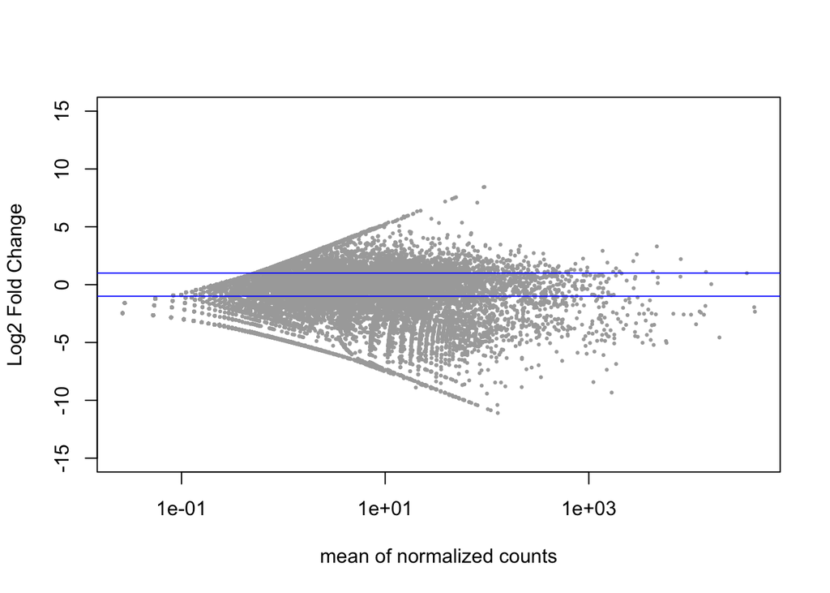

```r
abcghi_fig <- deseq2.res
# The main plot
plot(abcghi_fig$baseMean, abcghi_fig$log2FoldChange, pch=20, cex=0.45, ylim=c(-15, 15), log="x", col="darkgray",
     #main="ABC GHI  (pval </= 0.05)",
     xlab="mean of normalized counts",
     ylab="Log2 Fold Change")
# Getting the significant points and plotting them again so they're a different color
abcghi.sig <- deseq2.res[!is.na(deseq2.res$padj) & deseq2.res$padj <= 0.05, ]
points(abcghi.sig$baseMean, abcghi.sig$log2FoldChange, pch=20, cex=0.45, col="red")
# 2 FC lines
abline(h=c(-1,1), col="blue")
```

```r
write.table(abcghi.sig, "../analyses/DEG-ABCGHI.tab", row.names = T, quote = FALSE, sep = '\t')
```

```bash
head ../analyses/DEG-ABCGHI.tab
```

```
## baseMean log2FoldChange  lfcSE   stat    pvalue  padj
## TRINITY_DN1456_c0_g1_i1  19.9329644169108    22.2424764929734    3.68532349853711    6.03542036453586    1.58549405239259e-09    1.4165859796189e-05
## TRINITY_DN1994_c0_g2_i2  17.0394695821979    22.0256958707674    3.68896857251975    5.97069219695811    2.36249088081325e-09    1.4165859796189e-05
## TRINITY_DN365_c0_g1_i1   16.7179701561187    21.9984974649453    3.68960079860666    5.96229745864452    2.48715847253827e-09    1.4165859796189e-05
## TRINITY_DN3830_c0_g1_i1  17.6824684343563    22.0791432127655    3.68783959311746    5.98701289881786    2.13729839087896e-09    1.4165859796189e-05
## TRINITY_DN3962_c0_g1_i7  31.185444329683 22.8678290706108    3.68468542281194    6.20618219645991    5.4287237375793e-10 1.4165859796189e-05
```

```bash
wc -l ../analyses/DEG-ABCGHI.tab
```

```
##        6 ../analyses/DEG-ABCGHI.tab
```

# Heatmap - try getting vst for counts

```r
library(pheatmap)
```

```r
#transform data
vsd <- varianceStabilizingTransformation(deseq2.dds, blind = FALSE)#variance stabilizing transoformation
rld <- rlog(deseq2.dds, blind = FALSE) #controls for rows with few counts
```

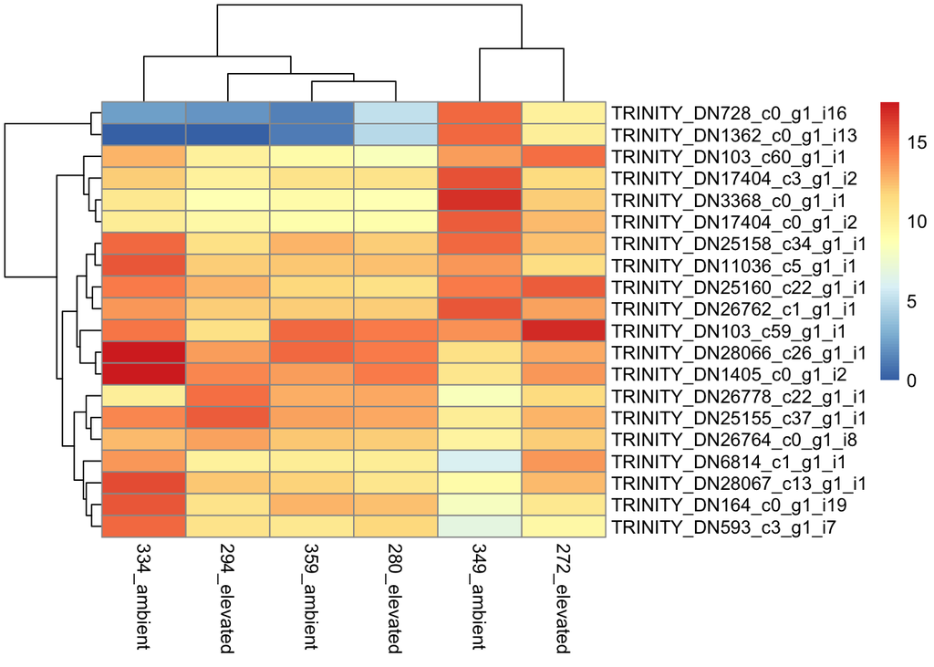

```r
ntd <- normTransform(deseq2.dds) #transforms data for plotting
top20 <- order(rowMeans(counts(deseq2.dds, normalized = TRUE)),
               decreasing = TRUE)[1:20] #average counts for each gene and select top 20 most abundant genes
pheatmap(assay(ntd)[top20,])
```

Try from DESeq2 manual: ntd heatmap

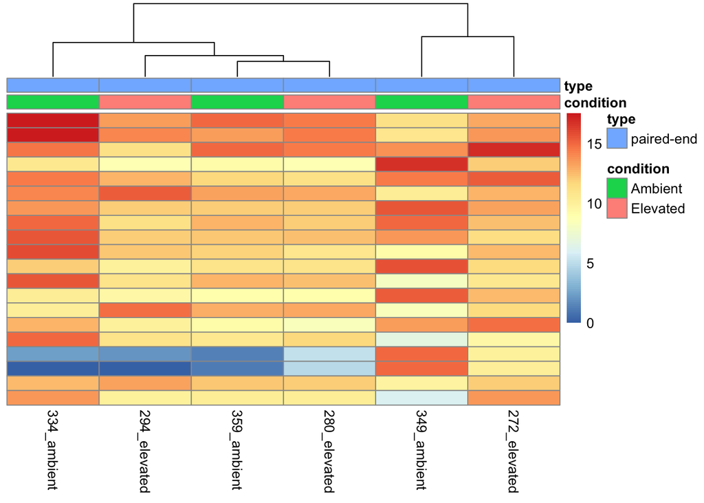

```r
select <- order(rowMeans(counts(deseq2.dds, normalized = TRUE)),
                decreasing = TRUE)[1:20]
df <- as.data.frame(colData(deseq2.dds)[,c("condition", "type")])
pheatmap(assay(ntd)[select,], cluster_rows = FALSE, show_rownames = FALSE, cluter_cols= FALSE, annotation_col = df)
```

vsd heatmap:

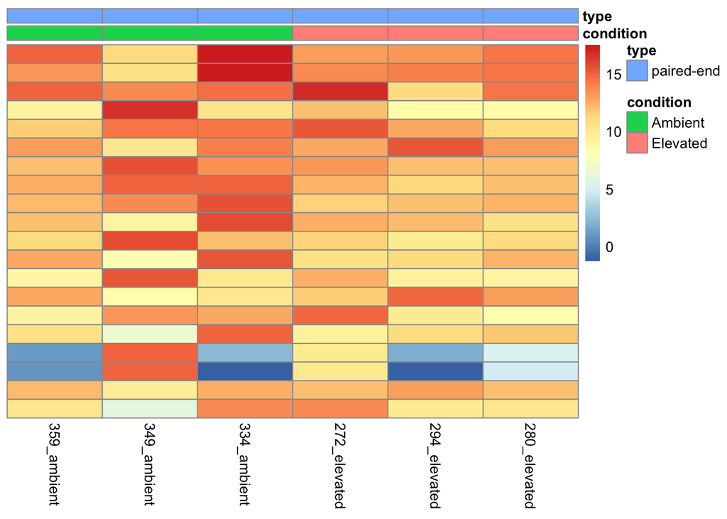

```r
pheatmap(assay(vsd)[select,], cluster_rows = FALSE, show_rownames = FALSE, cluster_cols = FALSE, annotation_col = df)
```

rld heatmap:

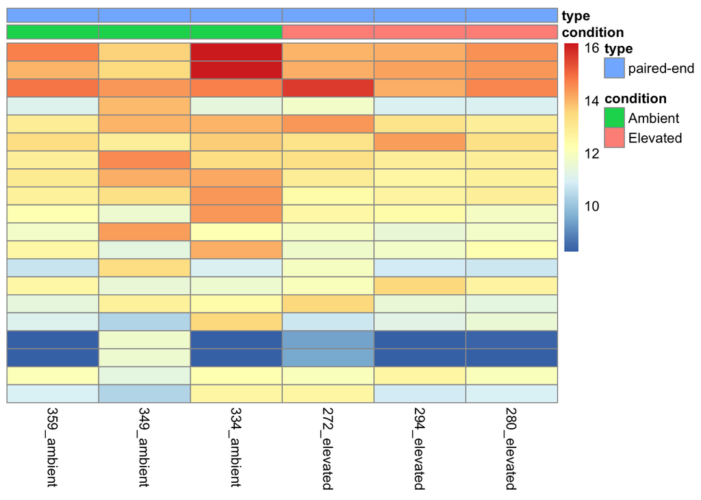

```r
pheatmap(assay(rld)[select,], cluster_rows = FALSE, show_rownames = FALSE, cluster_cols = FALSE, annotation_col = df)
```

Heatmap of sample to sample distances:

```r
sampleDists <- dist(t(assay(vsd)))
```

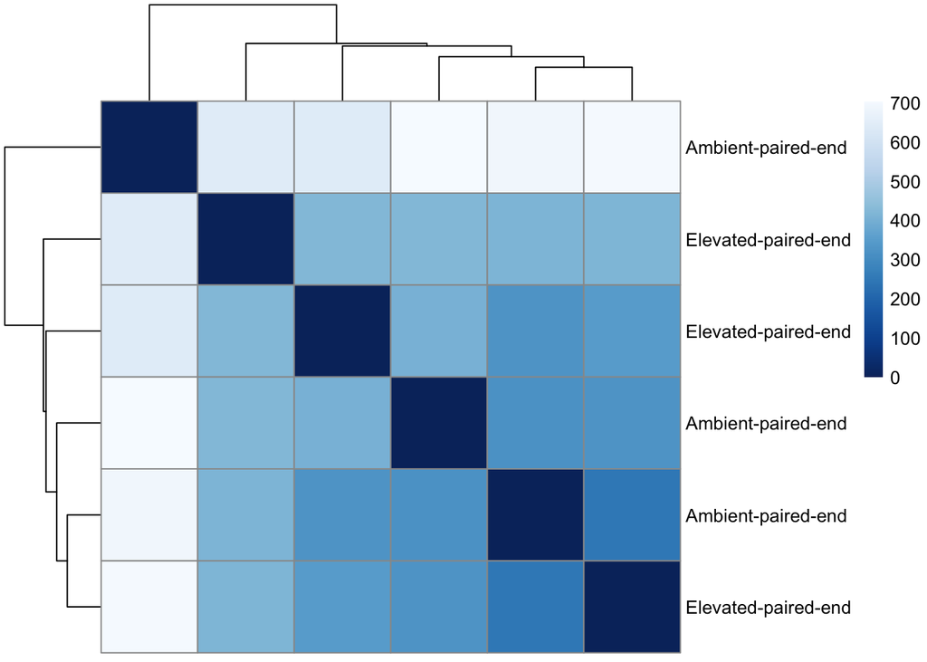

```r
library("RColorBrewer")
sampleDistMatrix <- as.matrix(sampleDists)
rownames(sampleDistMatrix) <- paste(vsd$condition, vsd$type, sep="-")
colnames(sampleDistMatrix) <- NULL
colors <- colorRampPalette( rev(brewer.pal(9, "Blues")) )(255)
pheatmap(sampleDistMatrix,
         clustering_distance_rows=sampleDists,
         clustering_distance_cols=sampleDists,
         col=colors)
```

PCA

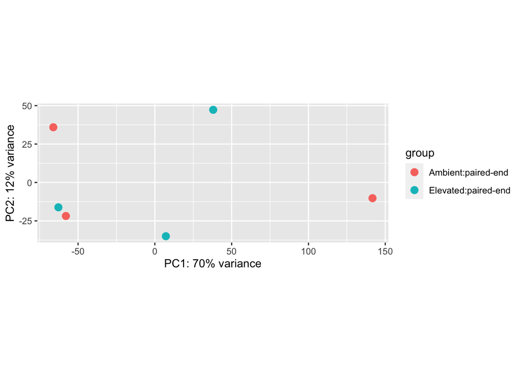

```r
plotPCA(vsd, intgroup=c("condition","type"))
```

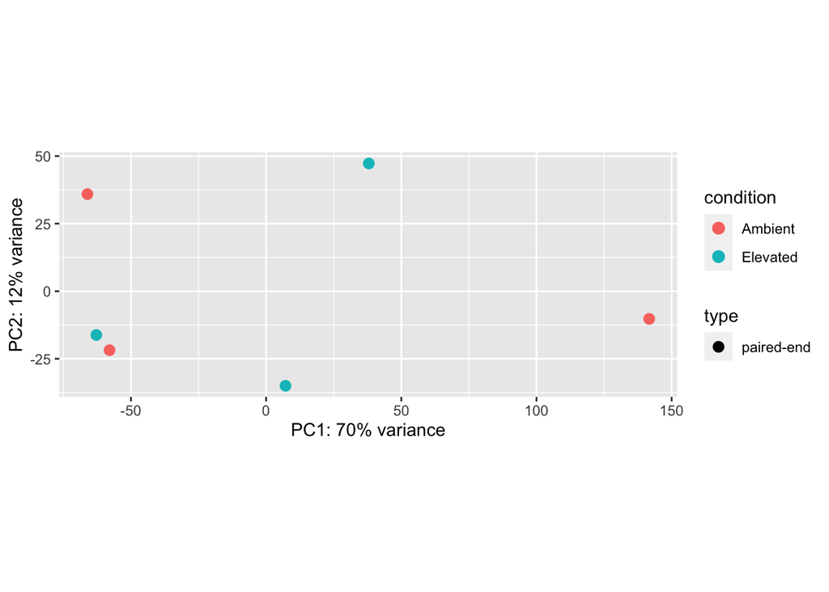

```r
pcaData <- plotPCA(vsd, intgroup=c("condition", "type"), returnData=TRUE)
percentVar <- round(100 * attr(pcaData, "percentVar"))
ggplot(pcaData, aes(PC1, PC2, color=condition, shape=type)) +
  geom_point(size=3) +
  xlab(paste0("PC1: ",percentVar[1],"% variance")) +
  ylab(paste0("PC2: ",percentVar[2],"% variance")) +
  coord_fixed()
```

Try to save the variance stabilized transformed data for use in other heatmaps:

```r
ABCGHI_vst_degs <- getVarianceStabilizedData(deseq2.dds)
head(ABCGHI_vst_degs)
```

```
##                          359_ambient 349_ambient 334_ambient 272_elevated
## TRINITY_DN5772_c0_g1_i1    0.2225923    -1.24163   -1.241630     -1.24163
## TRINITY_DN2201_c0_g1_i1   -1.2416301    -1.24163   -1.241630     -1.24163
## TRINITY_DN4656_c0_g1_i1    2.6670380    -1.24163    2.333682     -1.24163
## TRINITY_DN7591_c0_g1_i1    2.2512043    -1.24163   -1.241630     -1.24163
## TRINITY_DN6285_c0_g1_i4   -1.2416301    -1.24163   -1.241630     -1.24163
## TRINITY_DN28918_c0_g1_i1  -1.2416301    -1.24163   -1.241630     -1.24163
##                          294_elevated 280_elevated
## TRINITY_DN5772_c0_g1_i1    -1.2416301   -1.2416301
## TRINITY_DN2201_c0_g1_i1     0.6431368    2.1323190
## TRINITY_DN4656_c0_g1_i1     1.9841452    1.6670376
## TRINITY_DN7591_c0_g1_i1     1.7871823    0.9612592
## TRINITY_DN6285_c0_g1_i4    -1.2416301   -1.2416301
## TRINITY_DN28918_c0_g1_i1   -1.2416301   -1.2416301
```